# Supervised Learning Capstone: RoboZZle

### Jared Pollack

### May 2, 2020

# Introduction

### What is RoboZZle?

- RoboZZle = Robot + Puzzle
- video game available at robozzle.com, xBox ('Rob'), Android ('RoboZZle Droid')
- player programs a robot to pick up stars, which solves the puzzle
- all puzzles are designed by the players

### Gameplay and Features

- red, green, and blue tiles, or empty cells on a 16 x 12 grid
- functions and command slots
- commands: Forward, Left, Right, function calls
- paint & conditions

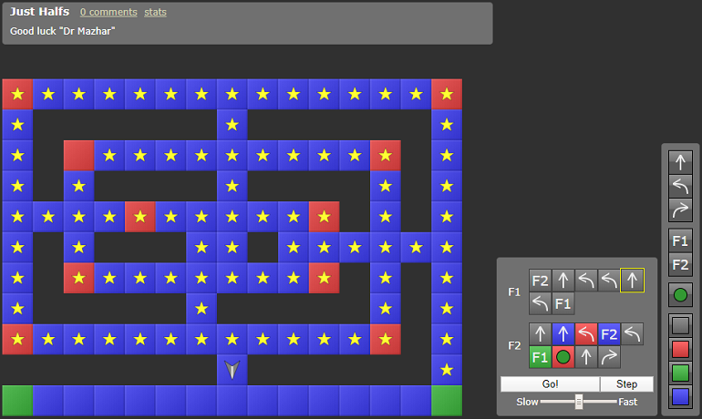

### Why RoboZZle

- I am both a player and designer
- it's why I started coding, which put me on the data science path
- Robozzle website maintains player and puzzle statistics
- process of solving puzzles has applications to reinforcement learning

### Finding a Target Variable

- players can vote on puzzles they solve
- 'Like' / 'Dislike' system similar to YouTube's 'thumbs-up' / 'thumbs-down' for videos
- outcomes and assigned values: Like = 1, Dislike = -1, Non-Vote = 0
- target variable: popularity

## Research Goals:

1. Determine the factors that influence the popularity of Robozzle puzzles
2. Construct models to predict a puzzle's popularity based on these factors (variables).

# 2. Collecting Data

- web-scraping required (no known RoboZZle data sets)
- 1st scrape (html): puzzle ID, title, author, date posted, players solved, liked/disliked, difficulty, solution lengths
- 2nd scrape (JavaScript): tiles, functions, command slots, stars, paint
- store data in python dictionaries; convert to DataFrames
- final count: 8,603 puzzles

```python
puzzles
```

```
[{'puzzleid': 12796,
  'red_list': 43,
  'green_list': 41,
  'blue_list': 53,
  'stars': 36},
 {'puzzleid': 12795,
  'red_list': 13,
  'green_list': 15,
  'blue_list': 108,
  'stars': 10},
 {'puzzleid': 12794,
  'red_list': 2,
  'green_list': 9,
  'blue_list': 9,
  'stars': 2}]
```

## Data Overview

#### Numeric Variables

- puzzleid (int)
- difficulty (float) : 1 (easy) - 5 (hard)
- players_solved (int)
- solution lengths (int) : variables for mean (float), min (int), and mode (int); multimodal = 0
- likes (int)
- dislikes (int)
- functions (int) : 1 - 5
- commands (int) : 1 - 50
- paint (int/bool) : yes = 1; no = 0
- number of red, green, blue tiles (int)
- stars (int)

### Categorical and Datetime Variables

- Categorical: title, author
- Datetime: date posted

title: may affect popularity; but dropped assuming author will be a stronger feature.

author: utilize dummy variables

date posted: convert to day posted (set 1st puzzle at day 1, and all others relative)

### Quick Note on RoboZZle

- RoboZZle launched over a decade ago
- initially popular, but interest has faded
- statistically speaking, players solved decreases with time (see plot below)
- smaller sample sizes result in greater variance
- expect models to perform better as players solved increases

### RoboZZle's Popularity Over Time

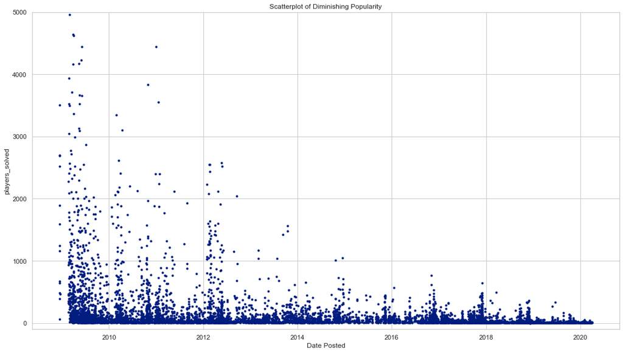

```python
plt.figure(figsize=(18, 10))
plt.scatter(robozzle.datetime_posted, robozzle.players_solved, marker='.')
plt.title('Scatterplot of Diminishing Popularity')
plt.xlabel('Date Posted'); plt.ylabel('players_solved')
plt.ylim(-100, 5000); plt.show()
```

## 3. Research Questions

Given the available statistics, how well can we:

1. Explain the variance in popularity of RoboZZle puzzles?
2. Predict the popularity of a RoboZZle puzzle?

# 4. EDA

## Univariate Analysis

- view distributions and descriptive stats for each variable
- apply Yeo-Johnson transformations

### Solution Lengths

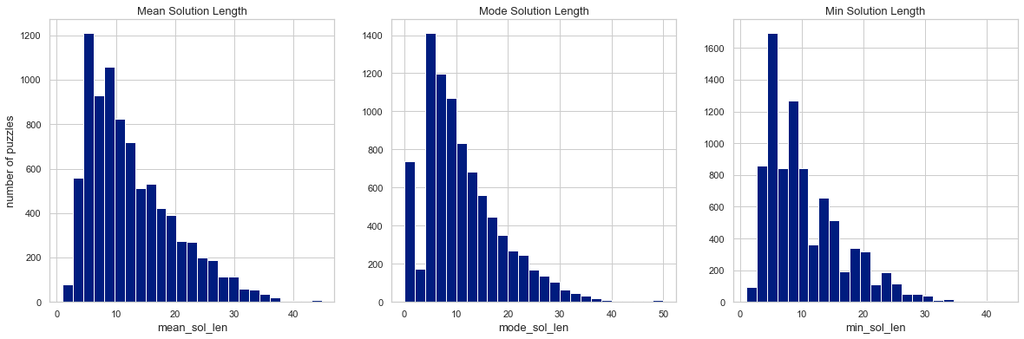

```python
plt.figure(figsize=(20, 6))
plt.subplot(1, 3, 1)
plt.hist(robozzle.mean_sol_len, bins=25)
plt.title('Mean Solution Length', fontsize=13)
plt.xlabel('mean_sol_len', fontsize=13); plt.ylabel('number of puzzles', fontsize=13)
plt.subplot(1, 3, 2)
plt.hist(robozzle.mode_sol_len, bins=25)
plt.title('Mode Solution Length', fontsize=13); plt.xlabel('mode_sol_len', fontsize=13)
plt.subplot(1, 3, 3)
plt.hist(robozzle.min_sol_len, bins=25)
plt.title('Min Solution Length', fontsize=13); plt.xlabel('min_sol_len', fontsize=13)
plt.show()
```

## Outliers

- for most variables, many outliers remain after Yeo-Johnson transformations
- individual outlier values checked for all variables
- all appear to be valid data points
- minimal winsorization applied (.005 and .995 quantiles)
- familiarity with RoboZZle data (domain knowledge) proves helpful

## Popularity Formulas and Distributions

- construct the formulas to represent popularity
- evaluate their distributions for normality and check for outliers
- apply transformations or treat outliers as needed

### Formulas:

1. popularity = (likes - dislikes) / players solved
2. popularity = Yeo-Johnson-transformed((likes - dislikes) / players solved)

### Popularity Metric Distributions

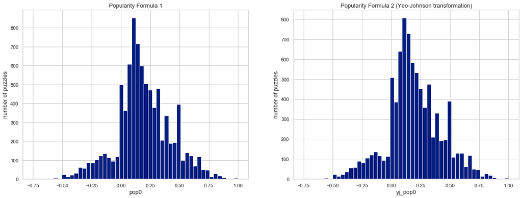

```python
plt.figure(figsize=(20, 7)); plt.subplot(1, 2, 1); plt.hist(robozzle.pop0, bins=50)
plt.title('Popularity Formula 1', fontsize=13); plt.xlabel('pop0', fontsize=13)
plt.ylabel('number of puzzles', fontsize=13); plt.subplot(1, 2, 2)
plt.hist(robozzle.yj_pop0, bins=50)
plt.title('Popularity Formula 2 (Yeo-Johnson transformation)', fontsize=13)
plt.xlabel('yj_pop0', fontsize=13); plt.ylabel('number of puzzles', fontsize=13)
plt.show()
```

## Categorical Distributions

### Author

- over 1,500 authors account for 8,600 puzzles
- impractical to create 1,500 dummy variables
- assign a value of 'other' to authors with fewer than *n* puzzles submitted
- test on range of values to determine an optimum threshold
- distribution will depend on threshold

#### author.value_counts < 100

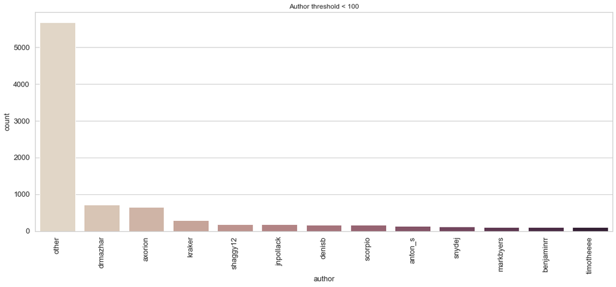

```python
rob_std = robozzle[(robozzle.players_solved > 0) & (robozzle.players_solved < 14500)]
rob_std.loc[rob_std['author'].isin((rob_std['author'].value_counts()[rob_std['author'].value_counts() < 100]).index), 'author'] = 'other'; plt.figure(figsize=(18, 7))
abc = sns.countplot(x='author', palette="ch:.25", data=rob_std, order=rob_std['author'].value_counts().index); plt.title('Author threshold < 100')
plt.xlabel('author', fontsize=13); plt.ylabel('count', fontsize=13); plt.xticks(fontsize=13, rotation=90); plt.yticks(fontsize=13); plt.show()
```

#### author.value_counts < 50

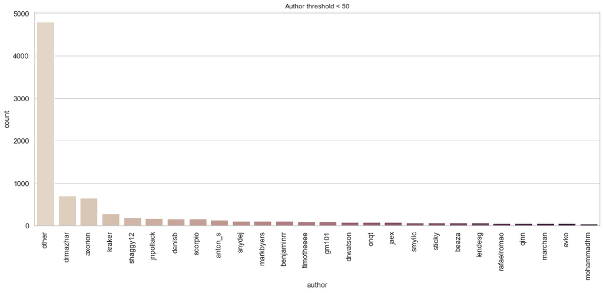

```python
rob_std = robozzle[(robozzle.players_solved > 0) & (robozzle.players_solved < 14500)]
rob_std.loc[rob_std['author'].isin((rob_std['author'].value_counts()[rob_std['author'].value_counts() < 50]).index), 'author'] = 'other'; plt.figure(figsize=(18, 7))
sns.countplot(x='author', palette="ch:.25", data=rob_std, order=rob_std['author'].value_counts().index); plt.title('Author threshold < 50')
plt.xlabel('author', fontsize=13); plt.ylabel('count', fontsize=13); plt.xticks(fontsize=13, rotation=90); plt.yticks(fontsize=13); plt.show()
```

#### author.value_counts < 6

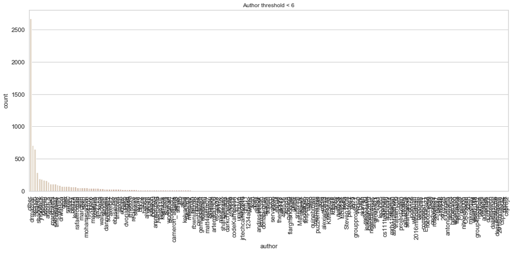

```python
rob_std = robozzle[(robozzle.players_solved > 0) & (robozzle.players_solved < 14500)]
rob_std.loc[rob_std['author'].isin((rob_std['author'].value_counts()[rob_std['author'].value_counts() < 6]).index), 'author'] = 'other'; plt.figure(figsize=(18, 7))
sns.countplot(x='author', palette="ch:.25", data=rob_std, order=rob_std['author'].value_counts().index); plt.title('Author threshold < 6')
plt.xlabel('author', fontsize=13); plt.ylabel('count', fontsize=13); plt.xticks(fontsize=13, rotation=90); plt.yticks(fontsize=13); plt.show()
```

- author_counts < 100 creates 13 dummies
- author_counts < 50 creates 26 dummies
- author_counts < 6 creates 212 dummies
- at high thresholds, less-accomplished authors have more statistical leverage
- at low thresholds, the feature set expands rapidly
- optimum threshold to be determined during modeling

## Multivariate Analysis

Several scatterplots of paired variables showed linear relationships. For example, the plot below shows a positive correlation between difficulty and popularity.

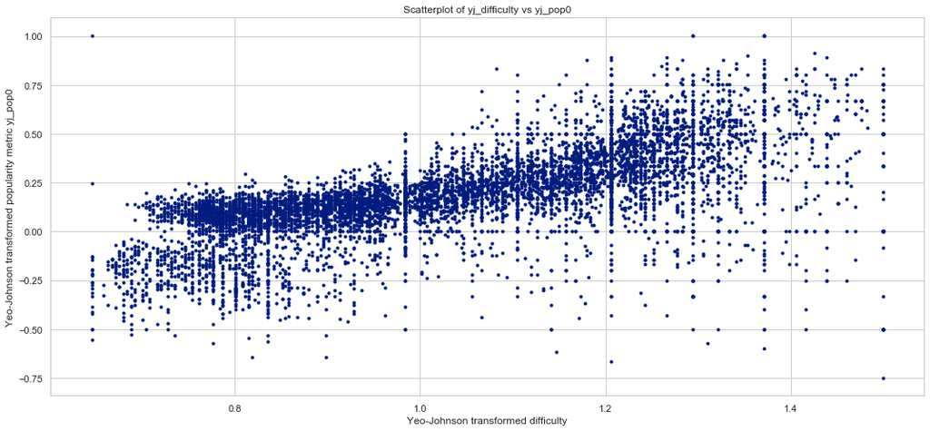

```python
plt.figure(figsize=(18, 8)); plt.scatter(robozzle.yj_difficulty, robozzle.yj_pop0, marker='.'); plt.title('Scatterplot of yj_difficulty vs yj_pop0')
plt.xlabel('Yeo-Johnson transformed difficulty'); plt.ylabel('Yeo-Johnson transformed popularity metric yj_pop0'); plt.show()
```

## Correlation Matrix

- verifies declining popularity; negative coefficients between puzzleid and players_solved, or day_posted and dislikes

```python
robozzle.corr()
```

|  | puzzleid | players_solved | likes | dislikes | day_posted_yj | yj_difficulty | yj_mean_sol_len | yj_mode_sol_len | yj_min_sol_len | pop0 | yj_pop0 | functions | commands | paint | red_tiles | green_tiles | blue_tiles | stars |
| --- | --- | --- | --- | --- | --- | --- | --- | --- | --- | --- | --- | --- | --- | --- | --- | --- | --- | --- |
| puzzleid | 1.000000 | -0.184375 | -0.188880 | -0.223145 | 0.962808 | -0.144143 | 0.083456 | -0.024203 | 0.104219 | -0.011570 | -0.010618 | 0.085720 | 0.044687 | 0.018590 | -0.057134 | -0.069688 | 0.064893 | 0.076224 |
| players_solved | -0.184375 | 1.000000 | 0.987644 | 0.788436 | -0.220657 | -0.137431 | -0.165511 | -0.081103 | -0.163731 | -0.020284 | -0.020065 | -0.143227 | -0.126029 | -0.061335 | -0.028661 | -0.028276 | -0.057946 | -0.060320 |
| likes | -0.188880 | 0.987644 | 1.000000 | 0.775152 | -0.233130 | -0.092092 | -0.136880 | -0.063700 | -0.133355 | 0.011858 | 0.011831 | -0.121965 | -0.113747 | -0.056052 | -0.024502 | -0.024727 | -0.047102 | -0.048725 |
| dislikes | -0.223145 | 0.788436 | 0.775152 | 1.000000 | -0.243311 | -0.306078 | -0.248107 | -0.131964 | -0.274972 | -0.160799 | -0.159691 | -0.174982 | -0.114186 | -0.088597 | 0.003133 | -0.017803 | -0.088794 | -0.104254 |
| day_posted_yj | 0.962808 | -0.220657 | -0.233130 | -0.243311 | 1.000000 | -0.194984 | 0.082350 | -0.023603 | 0.092533 | -0.082576 | -0.081396 | 0.094387 | 0.071857 | 0.026792 | -0.050277 | -0.060878 | 0.048169 | 0.058515 |
| yj_difficulty | -0.144143 | -0.137431 | -0.092092 | -0.306078 | -0.194984 | 1.000000 | 0.560993 | 0.300076 | 0.653273 | 0.639317 | 0.635036 | 0.334512 | 0.198719 | 0.170001 | 0.027563 | 0.080032 | 0.239125 | 0.314794 |
| yj_mean_sol_len | 0.083456 | -0.165511 | -0.136880 | -0.248107 | 0.082350 | 0.560993 | 1.000000 | 0.536723 | 0.941780 | 0.410958 | 0.407522 | 0.772576 | 0.732999 | 0.102780 | 0.027395 | 0.047100 | 0.185602 | 0.244049 |
| yj_mode_sol_len | -0.024203 | -0.081103 | -0.063700 | -0.131964 | -0.023603 | 0.300076 | 0.536723 | 1.000000 | 0.532939 | 0.281163 | 0.280012 | 0.367983 | 0.316452 | 0.004821 | -0.012765 | 0.004702 | 0.074728 | 0.110140 |
| yj_min_sol_len | 0.104219 | -0.163731 | -0.133355 | -0.274972 | 0.092533 | 0.653273 | 0.941780 | 0.532939 | 1.000000 | 0.503743 | 0.499741 | 0.668850 | 0.567025 | 0.106627 | -0.007291 | 0.015710 | 0.221141 | 0.297181 |
| pop0 | -0.011570 | -0.020284 | 0.011858 | -0.160799 | -0.082576 | 0.639317 | 0.410958 | 0.281163 | 0.503743 | 1.000000 | 0.999237 | 0.209429 | 0.093103 | 0.104891 | -0.002482 | 0.035663 | 0.174478 | 0.258029 |
| yj_pop0 | -0.010618 | -0.020065 | 0.011831 | -0.159691 | -0.081396 | 0.635036 | 0.407522 | 0.280012 | 0.499741 | 0.999237 | 1.000000 | 0.207230 | 0.091988 | 0.105215 | -0.002987 | 0.035952 | 0.173208 | 0.256287 |
| functions | 0.085720 | -0.143227 | -0.121965 | -0.174982 | 0.094387 | 0.334512 | 0.772576 | 0.367983 | 0.668850 | 0.209429 | 0.207230 | 1.000000 | 0.760669 | 0.080493 | 0.067345 | 0.069227 | 0.160047 | 0.166537 |
| commands | 0.044687 | -0.126029 | -0.113747 | -0.114186 | 0.071857 | 0.198719 | 0.732999 | 0.316452 | 0.567025 | 0.093103 | 0.091988 | 0.760669 | 1.000000 | 0.119630 | 0.094809 | 0.074989 | 0.097742 | 0.126795 |
| paint | 0.018590 | -0.061335 | -0.056052 | -0.088597 | 0.026792 | 0.170001 | 0.102780 | 0.004821 | 0.106627 | 0.104891 | 0.105215 | 0.080493 | 0.119630 | 1.000000 | -0.000374 | 0.022995 | 0.111395 | 0.148461 |
| red_tiles | -0.057134 | -0.028661 | -0.024502 | 0.003133 | -0.050277 | 0.027563 | 0.027395 | -0.012765 | -0.007291 | -0.002482 | -0.002987 | 0.067345 | 0.094809 | -0.000374 | 1.000000 | 0.138337 | -0.070896 | 0.164309 |
| green_tiles | -0.069688 | -0.028276 | -0.024727 | -0.017803 | -0.060878 | 0.080032 | 0.047100 | 0.004702 | 0.015710 | 0.035663 | 0.035952 | 0.069227 | 0.074989 | 0.022995 | 0.138337 | 1.000000 | -0.103839 | 0.174370 |
| blue_tiles | 0.064893 | -0.057946 | -0.047102 | -0.088794 | 0.048169 | 0.239125 | 0.185602 | 0.074728 | 0.221141 | 0.174478 | 0.173208 | 0.160047 | 0.097742 | 0.111395 | -0.070896 | -0.103839 | 1.000000 | 0.395446 |
| stars | 0.076224 | -0.060320 | -0.048725 | -0.104254 | 0.058515 | 0.314794 | 0.244049 | 0.110140 | 0.297181 | 0.258029 | 0.256287 | 0.166537 | 0.126795 | 0.148461 | 0.164309 | 0.174370 | 0.395446 | 1.000000 |

#### Strange Correlations?

1. blue tiles more highly correlated with other variables than red and green... why?

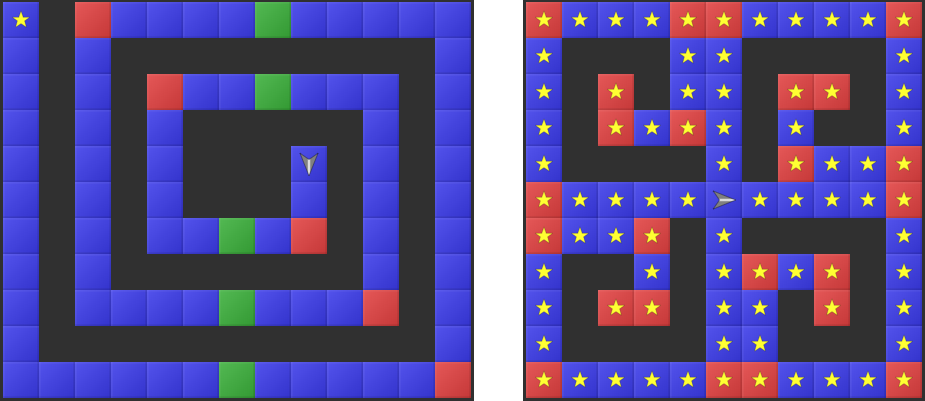

Tradition! Designers usually use blue tiles as the main path for the robot, and use red and green tiles to signal turns.

1. correlation between mean solution length and commands... should it be stronger?

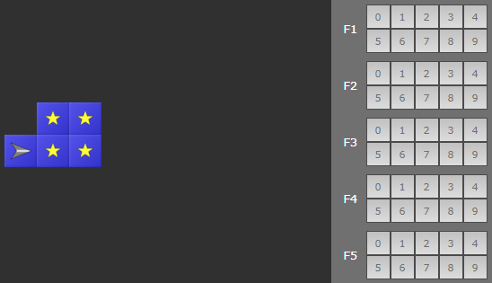

Inexperienced authors often submit puzzles with all 50 command slots available, when only a few are needed to solve the puzzle. (Solution: Forward, Forward, Left, Forward, Left, Forward; Solution length: 6 commands)

### Formal Hypothesis Test

- choose a variable to determine if it has any explanatory power for the target
- Plot regression line for min_sol_len vs. popularity

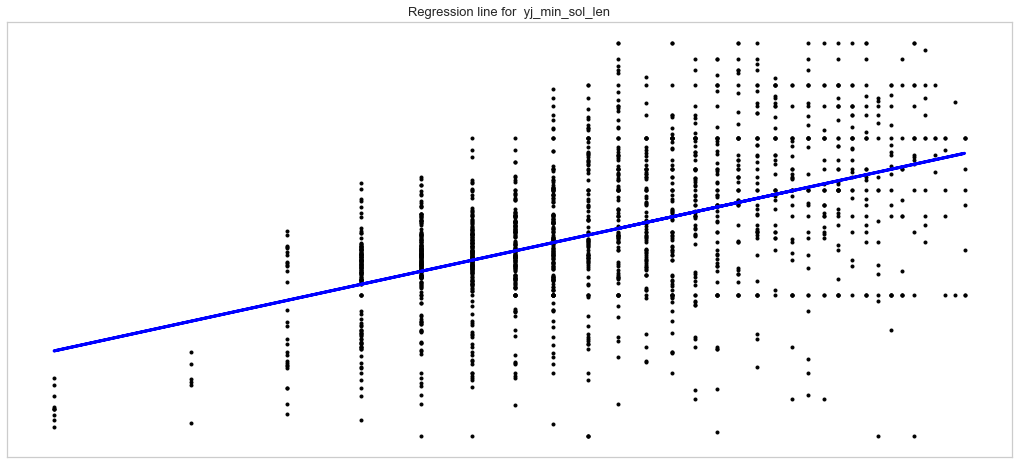

```python
plt.figure(figsize=(18, 8)); plt.scatter(x_test, y_test, marker='.', color='black')
plt.plot(x_test, y_preds_test, color='blue', linewidth=3)
plt.title('Regression line for  yj_min_sol_len', fontsize=13)
plt.xticks(()); plt.yticks(()); plt.show()
```

### Rejecting the Null

# 5. Models

### Preliminary Tests

1. determine an upper limit on players_solved
2. find the optimum threshold for author counts
3. choose popularity metric for modeling

#### 1. Upper Limit on players_solved

- used linear regression to test 5 thresholds: players_solved < 14,500; 10,000; 5,000; 2,000; 1,000
- while loop with each test threshold along with increasing lower threshold starting with `players_solved > 0`
- loop terminates when lower threshold filters more than half of data set

Here is a snippet:

```
i = 0
frac_dataset = 1
while frac_dataset > 0.5:
    rob_std = robozzle[(robozzle.players_solved > i) & (robozzle.players_solved < 14500)]
    frac_dataset = len(X)/8603
    i += 1
```

- averaged mean squared error results
- lowest average MSE: players_solved < 14,500 (will be used for modeling)
- complete code omitted due to time constraints

#### 2. Optimum Threshold for author counts

- used linear regression to test thresholds from 100 down to 6
- nested loop to vary players_solved lower threshold

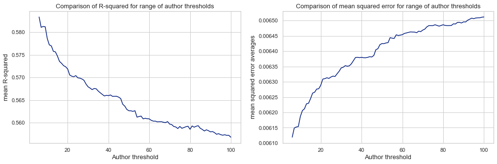

```python
plt.figure(figsize=(17, 5)); plt.subplot(1, 2, 1);
plt.plot(auth_test_all.author_th, auth_test_all.mean_r2)
plt.title('Comparison of R-squared for range of author thresholds', fontsize=13)
plt.xlabel('Author threshold', fontsize=13); plt.ylabel('mean R-squared', fontsize=13)
plt.subplot(1, 2, 2); plt.title('Comparison of mean squared error for range of author thresholds', fontsize=13)
v1 = plt.plot(auth_test_all.author_th, auth_test_all.mean_mse)
plt.xlabel('Author threshold', fontsize=13); plt.ylabel('mean squared error averages', fontsize=13); plt.show()
```

As the threshold increases, R-squared decreases, and MSE increases. The threshold will be set at 6, producing 212 dummy variables.

Lowering the threshold further would cause rapid expansion of the feature set.

```python
author_counts = robozzle.author.value_counts()
i = 7
while i > 0:
    num_dummies = len(author_counts[author_counts >= i])
    print('Setting the threshold at {} would result in {} dummy variables.'.format(i, num_dummies))
    i -= 1
```

```
Setting the threshold at 7 would result in 156 dummy variables.
Setting the threshold at 6 would result in 212 dummy variables.
Setting the threshold at 5 would result in 356 dummy variables.
Setting the threshold at 4 would result in 454 dummy variables.
Setting the threshold at 3 would result in 576 dummy variables.
Setting the threshold at 2 would result in 830 dummy variables.
Setting the threshold at 1 would result in 1516 dummy variables.
```

#### 3. Choosing the Popularity Metric

- again used linear regression to test both variables across a range of players_solved thresholds
- python dictionaries capture scores and are converted to DataFrames for analysis

## R-Squared

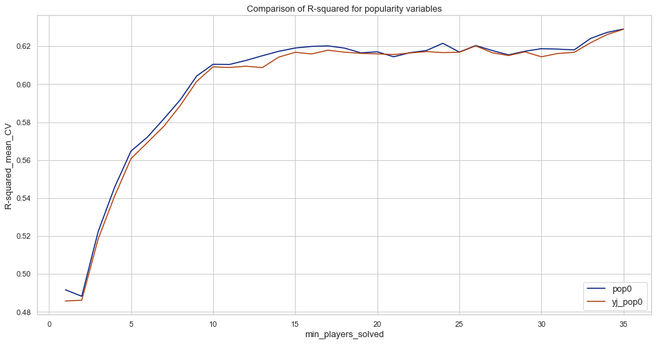

```python
var1, var2 = pd.DataFrame(lr_var1), pd.DataFrame(lr_var2); plt.figure(figsize=(16, 8))
v1r2 = plt.plot(var1.min_players_solved, var1['R-squared_mean_CV'], label='pop0')
v2r2 = plt.plot(var1.min_players_solved, var2['R-squared_mean_CV'], label='yj_pop0')
plt.title('Comparison of R-squared for popularity variables', fontsize=13); plt.xlabel('min_players_solved', fontsize=13)
plt.ylabel('R-squared_mean_CV', fontsize=13); plt.legend(loc='lower right', fontsize=13); plt.show()
```

## Mean Squared Error

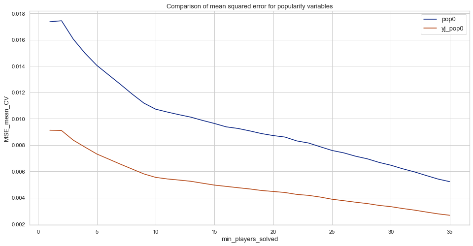

```python
plt.figure(figsize=(16, 8)); v1mse = plt.plot(var1.min_players_solved, var1['MSE_mean_CV'], label='pop0')
v2mse = plt.plot(var1.min_players_solved, var2['MSE_mean_CV'], label='yj_pop0')
plt.title('Comparison of mean squared error for popularity variables', fontsize=13)
plt.xlabel('min_players_solved', fontsize=13); plt.ylabel('MSE_mean_CV', fontsize=13)
plt.legend(loc='upper right', fontsize=13); plt.show()
```

### Assessment of Popularity Metrics

- R-squared: original variable performs slightly better
- mean squared error: Yeo-Johnson transformed variable performs substantially better

The transformed variable will be used for modeling, since it dominated the more crucial regression metric.

## Testing Assorted Models

- variety of sci-kit learn models: Linear, Orthogonal, Ridge, Support Vector, Gradient Boost, Random Forest
- K-Nearest Neighbors regression used with PCA; but couldn't handle the large feature set

# Results

- scores captured in dictionaries, then converted to DataFrames
- scores are then plotted for comparison

# Mean Squared Error

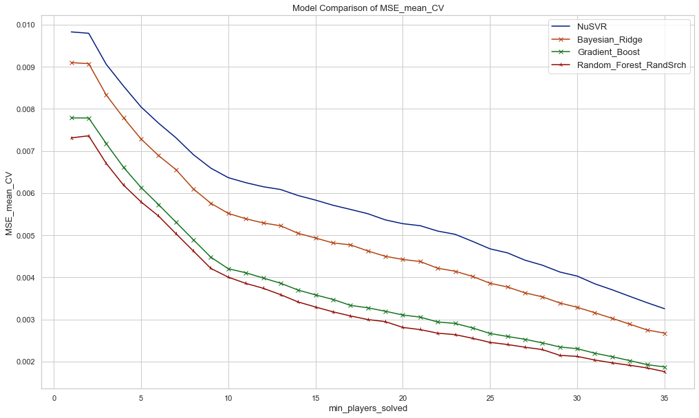

```python
plt.figure(figsize=(17, 10)); plt.title('Model Comparison of MSE_mean_CV', fontsize=13)
m1 = plt.plot(linear.min_players_solved, nusvr['MSE_mean_CV'], label='NuSVR')
m3 = plt.plot(linear.min_players_solved, bayesian_ridge['MSE_mean_CV'], marker="x", label='Bayesian_Ridge'); m4 = plt.plot(linear.min_players_solved, gbr['MSE_mean_CV'], marker="x", label='Gradient_Boost'); m7 = plt.plot(linear.min_players_solved, rfrrs['MSE_mean_CV'], marker="2", label='Random_Forest_RandSrch')
plt.xlabel('min_players_solved', fontsize=13); plt.ylabel('MSE_mean_CV', fontsize=13); plt.legend(loc='upper right', fontsize=13); plt.show()
```

### Mean Squared Error

- most important regression metric (squared difference between observed and predicted values)
- lower is better
- Nu Support Vector Regression: worst performer, long time to process
- Bayesian Ridge - Linear and Ridge models overlapping (removed for clarity)
- Gradient Boosting - 2nd best model (with GridSearchCV nearly identical)
- Random Forest with RandomizedSearchCV slightly outperformed standard RF (not shown)
- all models show consistent improvement as the players solved threshold increases, demonstrating the effect of sample size on predictability

# R-Squared

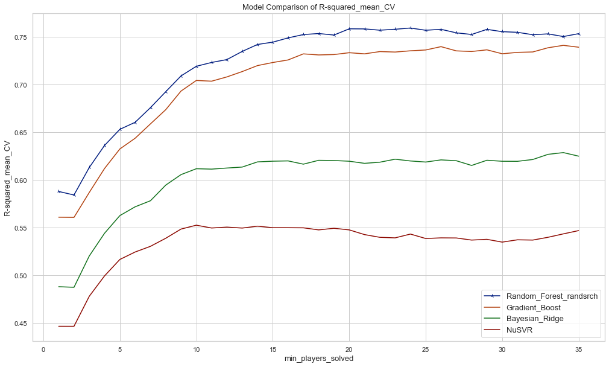

```python
plt.figure(figsize=(17, 10)); plt.title('Model Comparison of R-squared_mean_CV', fontsize=13); m10 = plt.plot(linear.min_players_solved, rfrrs['R-squared_mean_CV'], marker="2", label='Random_Forest_randsrch'); m4 = plt.plot(linear.min_players_solved, gbr['R-squared_mean_CV'], label='Gradient_Boost'); m5 = plt.plot(linear.min_players_solved, bayesian_ridge['R-squared_mean_CV'], label='Bayesian_Ridge')
m9 = plt.plot(linear.min_players_solved, nusvr['R-squared_mean_CV'], label='NuSVR')
plt.xlabel('min_players_solved', fontsize=13); plt.ylabel('R-squared_mean_CV', fontsize=13); plt.legend(loc='lower right', fontsize=13); plt.show()
```

### R-Squared

- proportion of variance in target variable predictable from features
- higher is better
- NuSVR again the worst model; showed decreasing scores when other models were steady
- Bayesian Ridge, Linear and Ridge: performance almost identical to one another
- Gradient Boost (standard and with GridSearchCV) again 2nd best model type
- Random Forests produce highest scores
- all models show sharp improvement as players solved threshold increases from 2 to about 10
- while proportion of explainable variance (R-squared) flattens around 15, MSE shows that prediction accuracy continues to improve

# 6. Conclusion

- RoboZZle more popular 11 years ago
- analysis of a niche game can still provide insights
- popularity prediction models utilized by YouTube; applicable to any entity or platform that captures user enjoyment
- comparing RoboZZle to YouTube: some metrics apply, others don't; highlights importance of collecting data that "tells the whole story"
- any company interested in the public's reception of product or service would benefit from reliable methods of estimating popularity

# Questions & Discussion

[figure not shown]

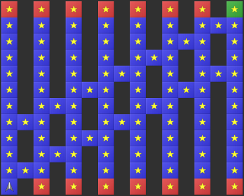

This research is dedicated to the memory of Dr. Mazhar.